# The Three Point Evolution of the Golden State Warriors

Coursework 1

Abdullah Nasir

19/03/2026

# Introduction

Modern basketball has undergone a dramatic transformation over the past few decades. One of the clearest examples of this change is the rise of the three-point shot, which is now a central part of offensive strategy in the NBA and other Basketball leagues.

Few teams represent this evolution better than the Golden State Warriors. Over the last decade, the team has helped to redefine modern basketball through a style of play built around spacing, ball movement, and long-range shooting. The success of players such as Stephen Curry accelerated the league-wide shift towards three-point-heavy offences.

This project explores how the number of three-point attempts by the Golden State Warriors has changed over time. Using NBA game data, I analyse the evolution of the team’s three-point shooting using time-series analysis. The data is then modelled using Meta’s Prophet forecasting system to identify long-term trends and generate forecasts.

[figure not shown]

# Dataset

The data used in this project comes from the **NBA Database (1947 – Present)** available on **Kaggle**, which contains detailed game-level statistics for NBA teams across many seasons.

Each row in the dataset represents the statistics for a team in a single NBA game and includes variables such as field goals, rebounds, assists, and three-point shooting. Because the dataset spans several decades, it allows us to examine long-term changes in playing style.

For this analysis, I focus on the variable `threePointersAttempted`, which records the number of three-point shots a team attempts in a game. Since the goal of this analysis is to study how the Golden State Warriors’ approach to three-point shooting has evolved over time, the dataset is filtered to include only games played by the Warriors.

The dataset also includes the game date in the `gameDateTimeEst` column. This variable allows the data to be organised as a time series so we can analyse trends in three-point shooting across different eras of NBA basketball.

```r
team_stats <- read.csv("data/TeamStatistics.csv")
```

# Preparing the Time Series

To analyse the Warriors’ three-point shooting over time, the dataset must first be prepared as a time series.

After preparing the data as a time series, the dataset is filtered to include only Golden State Warriors games. The game date variable is then converted to a standard date format to serve as the time index for the series.

In this project, we use the variable `threePointersAttempted` as the time series value.

Because the NBA introduced the three-point line in 1979, the analysis is restricted to games played since then. Additionally, data points with missing values are removed to ensure the model can be estimated correctly.

```r
warriors_stats <- subset(team_stats, teamName == "Warriors")

warriors_stats$gameDateTimeEst <- as.Date(warriors_stats$gameDateTimeEst)

warriors_ts <- data.frame(ds = warriors_stats$gameDateTimeEst, y = warriors_stats$threePointersAttempted)

warriors_ts <- subset(warriors_ts, ds >= as.Date("1979-01-01"))

warriors_ts <- na.omit(warriors_ts)
```

# Analysis

## Full Time Series Overview

We begin by visualising the full time series of Golden State Warriors three-point attempts per game since the introduction of the three-point line in 1979. This allows us to observe the overall long-term evolution of three-point shooting within the team.

Another notable aspect of the plot is the recurring gaps between groups of observations. These represent the NBA off-season, when no regular-season games occur. Each group thus indicates a single NBA season.

The variation between games is also evident. Some games feature far more three-point attempts due to factors such as opposing strategy, game tempo, and player availability.

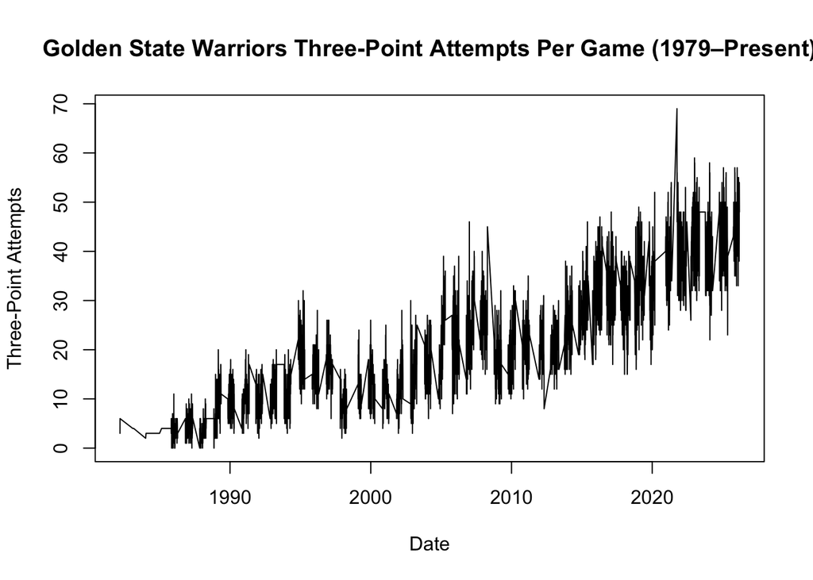

```r
plot(warriors_ts$ds, warriors_ts$y, type = "l", xlab = "Date", ylab = "Three-Point Attempts", main = "Golden State Warriors Three-Point Attempts Per Game (1979–Present)")
```

## The Modern Era: The Stephan Curry Effect

To better understand how the Warriors helped reshape modern basketball, it is useful to zoom in on the more recent period beginning around 2014.

This period marks the rise of Stephen Curry and the Warriors’ championship teams, built around heavy three-point shooting and floor spacing. As a result, during this era, the Warriors became one of the league’s most influential teams, contributing to what is often called the “three-point revolution.”

In the modern era, the spike in three-point attempts stands out. Many games now feature thirty to forty attempts, which was extremely rare in earlier decades.

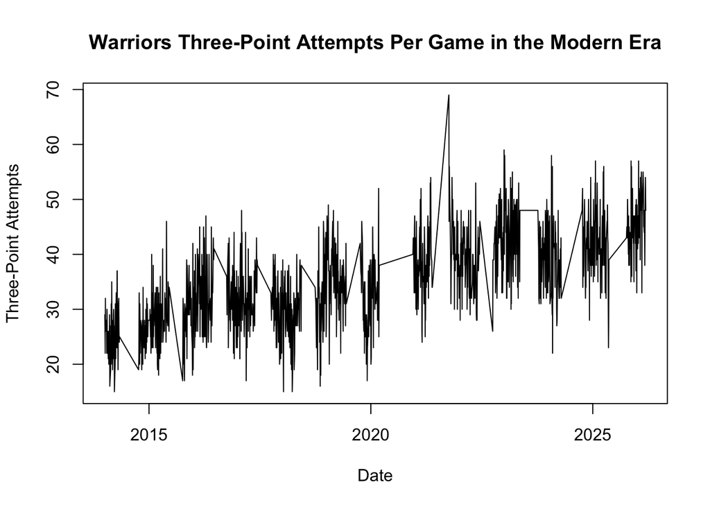

```r
modern_era <- subset(warriors_ts, ds >= as.Date("2014-01-01"))

plot(
  modern_era$ds,
  modern_era$y,
  type = "l",
  xlab = "Date",
  ylab = "Three-Point Attempts",
  main = "Warriors Three-Point Attempts Per Game in the Modern Era"
)
```

The time series contains a few outliers. One, in particular, stands out: the Warriors attempted 69 three-point shots in a single game.

This extreme value corresponds to a preseason game, which explains why it appears slightly separated from the main clusters of regular-season data in the time series. Preseason games are often used by teams to experiment with tactics and evaluate offensive systems before the competitive season begins.

For a team like the Warriors, whose system emphasises spacing and perimeter shooting, this environment makes it easier to push those strategies to the limit. While 69 attempts is clearly an extreme case, it reflects the team’s modern offensive philosophy and highlights how dramatically three-point usage has evolved compared with earlier eras of basketball.

## A Season in Focus

To better understand how shorter-term events can influence the time series, it is useful to zoom in on a single NBA season. The 2019–2020 season provides an interesting case study because the Warriors experienced major roster disruption and a long absence for Stephen Curry early in the year.

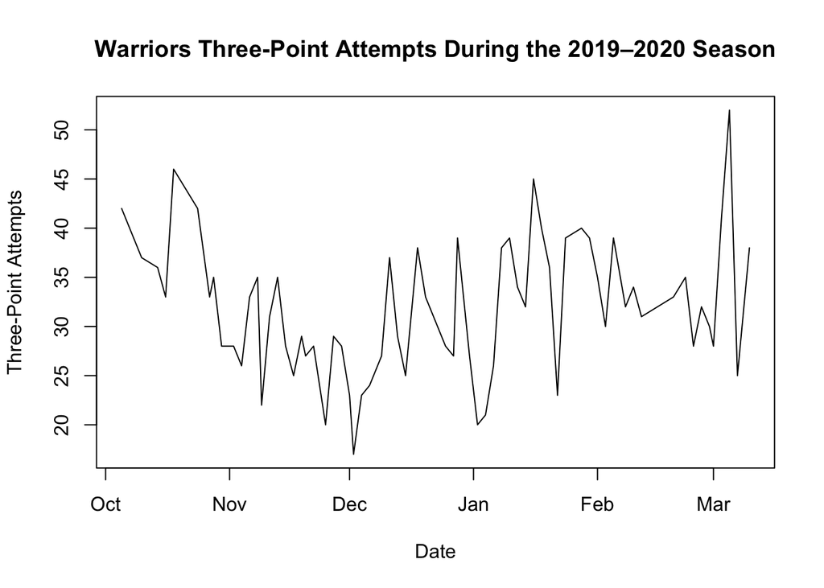

```r
season_2019 <- subset(
  warriors_ts,
  ds >= as.Date("2019-10-01") & ds <= as.Date("2020-04-01")
)

plot(
  season_2019$ds,
  season_2019$y,
  type = "l",
  xlab = "Date",
  ylab = "Three-Point Attempts",
  main = "Warriors Three-Point Attempts During the 2019–2020 Season"
)
```

The plot highlights several noticeable changes in three-point attempts throughout the season. At the start of the year, the Warriors attempted around 35–45 three-point shots per game. This reflects the offensive system built around perimeter shooting.

In December, the team faced heavy roster instability, frequently relying on younger or less experienced players. As a result, several games had noticeably lower attempt totals, including the lowest values shown in the plot.

Finally, the spike at the end of the series occurred shortly before the NBA suspended its 2019–2020 season in March 2020 due to the COVID-19 pandemic. Around this time, Stephen Curry briefly returned from injury, and his return led to a short-term increase in offensive production and three-point attempts.

Overall, this seasonal zoom shows how injuries, roster changes, and external events can influence a sports time series. These factors can affect team behaviour over short periods.

# Forecasting Model

To model the time series behaviour and generate future predictions, a forecasting model is fitted to the data. For this analysis, the **Prophet** model is used. Prophet is a forecasting tool designed for time series data and is particularly useful for capturing long-term trends and seasonal patterns.

The model is fitted to the Warriors’ three-point attempts time series.

```r
library(prophet)
warriors_model <- prophet(warriors_ts)
```

```
## Disabling daily seasonality. Run prophet with daily.seasonality=TRUE to override this.
```

After fitting the model, future dates are generated and predictions are produced for those time points.

```r
future <- make_future_dataframe(warriors_model, periods = 365)

forecast <- predict(warriors_model, future)
```

The resulting forecast contains predicted values along with uncertainty intervals for each future observation. These predictions can then be visualised and interpreted in the following section.

# Results & Discussion

After fitting the Prophet model, the forecast can be visualised to examine both the historical data and the model’s predicted future values.

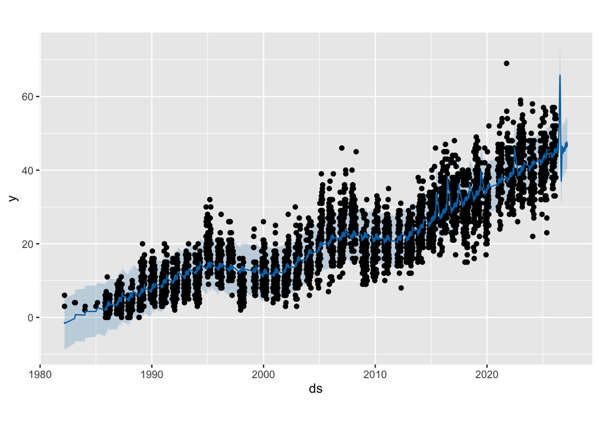

```r
plot(warriors_model, forecast)
```

The forecast plot displays historical observations and the model’s anticipated behaviour. Black points mark observed three-point attempts per Warriors game, while the blue line represents the Prophet model’s estimated trend. The shaded area indicates the uncertainty interval.

The model captures the clear upward trend in three-point attempts over time. In recent seasons, the Warriors have frequently attempted 40–50 three-point shots per game, reflecting the modern NBA’s strong emphasis on perimeter shooting.

The forecast indicates this high volume of three-point attempts will likely persist in the near future. However, sports data predictions require careful interpretation. As shown earlier, factors such as injuries, roster changes, and tactical shifts can significantly impact team behaviour.

Moreover, much of the Warriors’ offensive strategy has been defined by players such as Stephen Curry. If key players retire or teams adopt different tactics, the pattern of three-point attempts could shift. Therefore, the forecast should be considered an estimate based on historical patterns rather than a firm prediction.

Overall, this analysis shows that time-series analysis help track shifts in basketball strategy. Analysing the Golden State Warriors’ three-point attempts highlights that perimeter shooting is increasingly vital to the NBA, but forecasting future changes remains challenging.